[figure not shown]

# A Crash Course in Python

February 10, 2018

- Based on notes from Ch. 2 of [Data Science from Scratch](http://shop.oreilly.com/product/0636920033400.do) by Joel Grus.
- Download the Jupyter notebook for these slides [here](https://github.com/mepa/daysofcode-python/blob/gh-pages/index.ipynb).

## The Basics

- Getting Python
- The Zen of Python
- Whitespace Formatting
- Modules
- Arithmetic
- Functions
- Strings
- Exceptions
- Lists
- Tuples
- Dictionaries
  - `defaultdict`
  - `Counter`
- Sets
- Control Flow
- Truthiness

### Getting Python

- We recommend installing [Anaconda](https://store.continuum.io/cshop/anaconda/)
- Otherwise, you can install the following to get started:
  - [Python](https://www.python.org/)
  - Python package manager: pip
  - Nicer Python shell: [IPython](http://ipython.org/)
  - Web app for interactive data sci: [Jupyter Notebook](http://jupyter.org/)
    - `pip install jupyter` (Python 2)
    - `pip3 install jupyter` (Python 3)
  - etc...

**Best practice:** Begin each new Python project in its own virtual environment (using either `conda` or `pip` + `virtualenv`, for example)

- Check Myth #5 here for considerations on what to use: http://jakevdp.github.io/blog/2016/08/25/conda-myths-and-misconceptions/

### The Zen of Python

- Python design principles: [The Zen of Python (PEP 20)](https://www.python.org/dev/peps/pep-0020/)
- Python code readability: [Style Guide for Python Code (PEP 8)](https://www.python.org/dev/peps/pep-0008/)

### Whitespace Formatting

In Python, whitespace is important. Other languages, like C++, use curly braces {} to delimit blocks of code.

```
for( int i = 0; i < 5; i++ )
   {
       cout << i << endl;
   }
```

```python
# Python uses indentation to delimit blocks of code.
for i in range(5):
    print(i)
```

```
0
1
2
3
4
```

### Modules

- `import` modules (= libraries = packages) that aren't in the [Python 3.6 standard library](https://docs.python.org/3.6/library/)
- Python has a *huge* variety and number of extra packages that can be installed, if not already, with `pip` or `conda`, then imported:
  - [PyPI (Python Package Index)](https://pypi.python.org/pypi)
  - [Anaconda Package List](https://docs.continuum.io/anaconda/pkg-docs) ; additionally, check out these docs:
    - Also, check out "Packages available in Anaconda" and "Managing Packages in Anaconda" from [here](https://docs.continuum.io/anaconda/index#packages-available-in-anaconda)

Let's try importing the [Matplotlib pyplot module](http://matplotlib.org/api/pyplot_api.html), which "provides a MATLAB-like plotting framework."

*Note*:

- Sometimes you'll want to use [IPython magic commands](http://ipython.readthedocs.org/en/stable/interactive/magics.html) in your Jupyter notebooks.
- Try not to do the following since you may inadvertently overwrite variables you've already defined: `from matplotlib.pyplot import *`

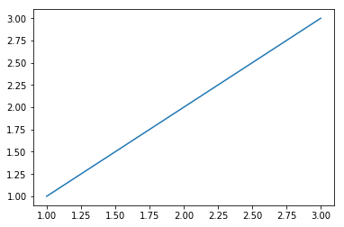

```python
# Tip: use IPython magic command "%matplotlib inline" to display plots in notebook
%matplotlib inline
import matplotlib.pyplot # import module and reference by its super long name

matplotlib.pyplot.plot([1,2,3], [1,2,3]) # must type the whole name to access methods, etc.
```

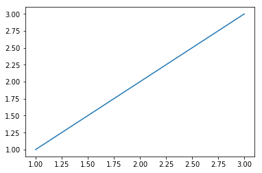

```python
import matplotlib.pyplot as plt # OR, alias it as a shorter, more fun-to-type name

plt.plot([1,2,3], [1,2,3])
```

### Arithmetic

- Python 3 uses float division by default.
- Python 2 (like Fortran) uses integer division by default.
  - To get float division as default:

    ```
    from __future__ import division
    ```

```python
print(5 / 2)
```

```
2.5
```

- Key differences between Python 2 and 3: http://sebastianraschka.com/Articles/2014_python_2_3_key_diff.html
- For motivation switch to Python3, see here: https://pythonclock.org/

```python
from __future__ import division
print(5 / 2)   # now floating point division is default
print(5 // 2)  # use double slash for integer division
```

```
2.5
2
```

### Functions

- Define functions with `def`

```python
def double(x):
    """This is where you put an optional docstring that
    explains what the function does.
    For example, this function multiplies its input by 2."""
    return x * 2
```

```python
def apply_to_one(f):
    """Calls the function f with 1 as its argument"""
    return f(1)
```

- Python functions are [first-class](https://en.wikipedia.org/wiki/First-class_function)

```python
my_double = double          # refers to the previously defined function
x = apply_to_one(my_double)
print(x)
```

```
2
```

#### `lambda` functions

- These are short, [anonymous functions](https://en.wikipedia.org/wiki/Anonymous_function)

```python
y = apply_to_one(lambda x: x + 4)
print(y)
```

```
5
```

```python
# but use `def` instead of assigning a lambda function to a variable
another_double = lambda x: 2 * x     # don't do this
def another_double(x): return 2 * x  # do this instead
```

#### default function arguments

- define a default arg; specify arg only if you want different value

```python
def my_print(message="my default message"):
    print(message)

my_print("hello")
```

```
hello
```

```python
my_print()
```

```
my default message
```

### Strings

```python
# Delimit strings with single OR double quotation marks
single_quoted_string = 'data science'
double_quoted_string = "data science"
print(single_quoted_string, "is the same as", double_quoted_string)
print("{} is the same as {}", single_quoted_string, double_quoted_string) # another way to format strings
```

```
data science is the same as data science
{} is the same as {} data science data science
```

```python
# Use backslashes to encode special characters
tab_string = "\t"  # represents the tab character
len(tab_string)    # string length is 1 (not 2)
```

```
1
```

```python
# Use raw strings to represent backslashes
not_tab_string = r"\t"  # represents the characters '\' and 't'
len(not_tab_string)     # now length is 2
```

```
2
```

```python
# Create multiline strings using triple-quotes
multi_line_string = """This is the first line.
and this is the second line
and this is the third line"""
print(multi_line_string)
```

```
This is the first line.
and this is the second line
and this is the third line
```

### Exceptions

```python
# This makes your code crash
# print(0 / 0)
```

[Here's](https://docs.python.org/2/library/exceptions.html) a list of built-in exceptions

```python
# This will handle the exception by printing an error message
try:
    print(0 / 0)
except ZeroDivisionError:
    print("Cannot divide by zero")
```

```
Cannot divide by zero
```

### Lists

- Ordered collections
- Similar to an array in other languages, but holds heterogeneous data (e.g., floats + ints + strings)
- *Note*: Use NumPy arrays ([here's](https://docs.scipy.org/doc/numpy-dev/user/quickstart.html) a tutorial) for larger amounts of homogeneous data (e.g., just floats)
- Specify with brackets `[]`

```python
integer_list = [1, 2, 3]
heterogeneous_list = ["string", 0.1, True]
list_of_lists = [ integer_list, heterogeneous_list, [] ]

print(len(integer_list))  # get the length of a list
print(sum(integer_list))  # get the sum of the elements in a list (if addition is defined for those elements)
```

```
3
6
```

```python
# Use square brackets to get the n^{th} element of a list
x = range(10)
print(x)
print(x[0])
print(x[1])
print(x[-1])
print(x[-2])
```

```
range(0, 10)
0
1
9
8
```

```python
# Use square brackets to "slice" lists
print(x[:3])   # up to but not including 3
print(x[3:])   # 3 and up
print(x[1:4])  # 1 up to but not including 4
print(x[-3:])  # last 3
print(x[1:-1]) # without 1 and 9
print(x[:])    # all elements of the list
```

```
range(0, 3)
range(3, 10)
range(1, 4)
range(7, 10)
range(1, 9)
range(0, 10)
```

```python
# Use the `in` operator to check for list membership; use only for small lists or if run time is not a concern
print(1 in [1, 2, 3])
print(0 in [1, 2, 3])
```

```
True
False
```

```python
# Concatenate lists like this
x = [1, 2, 3]

y = x + [4, 5, 6]   # creates a new list leaving "x" unchanged
print(x)
print(y, "\n")

x.extend([4, 5, 6]) # changes "x"
print(x)
```

```
[1, 2, 3]
[1, 2, 3, 4, 5, 6]

[1, 2, 3, 4, 5, 6]
```

```python
# Append to lists like this
x = [1, 2, 3]
print(x, "\n")

x.append(0)
print(x)
```

```
[1, 2, 3]

[1, 2, 3, 0]
```

```python
# It's convenient (and common) to unpack lists like this
z = [1, 2]
x, y = z
print(type(x), "x =", x)
print(type(y), "y =", y)
print(type(z), "z =", z)
```

```
<class 'int'> x = 1
<class 'int'> y = 2
<class 'list'> z = [1, 2]
```

```python
# It's also common to use an underscore for a value you're going to throw away
z = [3, 4]
_, y = z
print(x)
print(y)
print(z)
```

```
1
4
[3, 4]
```

### Tuples

- Similar to list, but immutable (can't be modified)
- Specify with parentheses`()` or nothing

```python
my_list = [1, 2]
my_tuple = (1, 2)
other_tuple = 3, 4
my_list[1] = 3

print(my_list)
```

```
[1, 3]
```

```python
try:
    my_tuple[1] = 3
except TypeError:
    print("Cannot modify a tuple")
```

```
Cannot modify a tuple
```

```python
# Use tuples to return multiple values from functions
def sum_and_product(x, y):
    return (x + y), (x * y)

sp = sum_and_product(2, 3)
s, p = sum_and_product(5, 10)
print(sp)
print(s)
print(p)
```

```
(5, 6)
15
50
```

```python
# Use tuples (and lists) for multiple assignments
x, y = 1, 2
print("x =", x)
print("y =", y)
```

```
x = 1
y = 2
```

```python
x, y = y, x  # Pythonic way to swap variables
print("x =", x)
print("y =", y)
```

```
x = 2
y = 1
```

### Dictionaries

- Dictionaries associate *values* with *keys*
- Allow quick retrieval of value given a key
- Specify with curly braces `{}` or `dict()`

```python
empty_dict = {}                    # Pythonic
empty_dict2 = dict()               # less Pythonic
grades = { "Joel": 80, "Tim": 95}

# Use square brackets to look up value(s) for a key
print(grades["Joel"])
```

```
80
```

```python
# KeyError exception raised if key not found
try:
    kates_grade = grades["Kate"]
except KeyError:
    print("No grade for Kate!")
```

```
No grade for Kate!
```

```python
# Use `in` to check for existence of a key
joel_has_grade = "Joel" in grades
kate_has_grade = "Kate" in grades

print(joel_has_grade)
print(kate_has_grade)
```

```
True
False
```

```python
# Use `get` method of dictionaries when you want to return a default value (rather than raise exception)
print(grades.get("Joel", 0))
print(grades.get("Kate", 0))
print(grades.get("No One"))
```

```
80
0
None
```

```python
# Use square brackets to assign key-value pairs, e.g., dict_name[key] = value
grades["Tim"] = 99
grades["Kate"] = 100

print("Number of students:", len(grades))
```

```
Number of students: 3
```

```python
# Use dictionaries to represent structured data, such as in a tweet
tweet = {
    "user": "joelgrus",
    "text": "Data Science is Awesome",
    "retweet_count": 100,
    "hashtags": ["#data", "#science", "#datascience", "#awesome"]
}
```

```python
print(tweet.keys())    # list of keys
print(tweet.values())  # list of values
print(tweet.items())   # list of (key, value) tuples
```

```
dict_keys(['user', 'text', 'retweet_count', 'hashtags'])
dict_values(['joelgrus', 'Data Science is Awesome', 100, ['#data', '#science', '#datascience', '#awesome']])
dict_items([('user', 'joelgrus'), ('text', 'Data Science is Awesome'), ('retweet_count', 100), ('hashtags', ['#data', '#science', '#datascience', '#awesome'])])
```

```python
print("user" in tweet.keys() )      # list `in` is slow
print("user" in tweet)              # dict `in` is fast (and more Pythonic)
print("joelgrus" in tweet.values())
```

```
True
True
True
```

You *cannot* use lists as keys. If that's needed, then:

- use a `tuple`, or
- represent the key as a string

#### Let's load some data to use in the upcoming examples on `defaultdict`

```python
# Load the data into a list called `tweets`
import json
# Substitute the local path to your three_minutes_tweets.json file within the quotes
tweet_file = open("data/three_minutes_tweets.json")

tweets = []
for line in tweet_file:
    tweets.append(json.loads(line)) # each list element contains all data pertaining to a single tweet
print("Total # of tweets:", len(tweets))
print("type(tweets[0]):", type(tweets[0]))
```

```
Total # of tweets: 8299
type(tweets[0]): <class 'dict'>
```

- For tweets that contain a "text" key we can print someone's tweet:

```python
print(tweets[7]['text'])  # text of 8th tweet
```

```
@1voodoochild thanks for the follow💯
```

```python
print(tweets[3]['text'])  # text of 4th tweet
```

```
إنّ العرب إذا تغلبوا على أوطان أسرع إليها الخراب والسبب في ذلك أنها أمة وحشية بإستحكام عوائد التوحش وأسبابه فصار لهم خلقة وجبلة

- ابن خلدون
```

*Aside*: The text is attributed to [Ibn Khaldun](https://en.wikipedia.org/wiki/Ibn_Khaldun) who lived 1332 - 1406.

From Google Translate:

**April 2016:** "The Arabs overcame their homelands if faster to ruin and why they are a nation and brutal savagery Bastgam returns and causes them became habitus and protoplasm"

**February 2018:** "The Arabs, if they overcome the worlds faster to ruin, and the reason that it is a brutal nation persistently the proceeds of brutality and its causes,"

```python
print(tweets[54]['text'])
```

```
@morgancollins42 I don't like you
```

```python
print(tweets[7000]['text'])
```

```
The Newf opened up and ate a whole bar of Ivory soap. Some things about the canine diet I will never understand.
```

```python
# Print all key-value pairs in the 54th tweet
for key in tweets[53].keys():
    print(key, ": \t", tweets[53][key])
```

```
created_at : 	 Sun Aug 16 21:41:14 +0000 2015
id : 	 633030783796514816
id_str : 	 633030783796514816
text : 	 I'm starving I can't wait to leave work and eat Wing Barn 😋🍗
source : 	 <a href="http://twitter.com/download/iphone" rel="nofollow">Twitter for iPhone</a>
truncated : 	 False
in_reply_to_status_id : 	 None
in_reply_to_status_id_str : 	 None
in_reply_to_user_id : 	 None
in_reply_to_user_id_str : 	 None
in_reply_to_screen_name : 	 None
user : 	 {'id': 509749471, 'id_str': '509749471', 'name': 'Ben✌', 'screen_name': 'BenitoAguirre1', 'location': 'harlingen, tx', 'url': None, 'description': '21 years old, Aquarius ♒️, Instagram _BENNYAGUIRRE, taken', 'protected': False, 'verified': False, 'followers_count': 149, 'friends_count': 206…
geo : 	 None
coordinates : 	 None
place : 	 None
contributors : 	 None
retweet_count : 	 0
favorite_count : 	 0
entities : 	 {'hashtags': [], 'trends': [], 'urls': [], 'user_mentions': [], 'symbols': []}
favorited : 	 False
retweeted : 	 False
possibly_sensitive : 	 False
filter_level : 	 low
lang : 	 en
timestamp_ms : 	 1439761274657
```

#### `defaultdict`

- Like a regular dictionary, except that when you try to look up a key that is not present in the dictionary, it first adds a value for it using a no-argument function that you provide when creating it.
- Imagine creating a dictionary to count the words in a document. Below are 3 approaches for doing that with a regular dictionary.

```python
# Load a document
html_file = open('data/The Jungle Book, by Rudyard Kipling.htm')
doctext = html_file.readlines()
html_file.close()

doctext[:10]  # show the first 10 lines
```

```
['<?xml version="1.0" encoding="utf-8"?>\n',
 '\n',
 '<!DOCTYPE html\n',
 '   PUBLIC "-//W3C//DTD XHTML 1.0 Strict//EN"\n',
 '   "http://www.w3.org/TR/xhtml1/DTD/xhtml1-strict.dtd" >\n',
 '\n',
 '<html xmlns="http://www.w3.org/1999/xhtml" lang="en">\n',
 '  <head>\n',
 '    <title>\n',
 '      The Jungle Book, by Rudyard Kipling\n']
```

```python
# Make a function to split the document into a list of words
import re

def tokenize(lines):
    """returns a list of distinct words contained in `lines`"""
    all_words = []
    for line in lines:
        line = line.lower()                       # convert to lowercase
        words = re.findall("[a-z0-9']+", line)   # extract the words
        all_words = all_words + words
    return all_words

document = tokenize(doctext)
```

```python
# Approach 1 - if/else statement
word_counts = {}
for word in document:
    if word in word_counts:
        word_counts[word] += 1
    else:
        word_counts[word] = 1
```

```python
# Approach 2 - handle the exception
word_counts = {}
for word in document:
    try:
        word_counts[word] += 1
    except KeyError:
        word_counts[word] = 1
```

```python
# Approach 3 - use `get`
word_counts = {}
for word in document:
    previous_count = word_counts.get(word, 0)
    word_counts[word] = previous_count + 1
```

Instead we can use `defaultdict` (needs to be imported from `collections`):

```python
from collections import defaultdict

word_counts = defaultdict(int)  # int(0) produces 0
for word in document:
    word_counts[word] += 1
```

```python
# Let's implement the example above, but substitute a tweet for "document"
from collections import defaultdict

tweet_text = tweets[2736]['text'].encode('utf-8') # returns one long string & encodes the text as unicode
tweet_words = tweet_text.split()                  # split() returns a list of words

word_counts = defaultdict(int)
for word in tweet_words:
    word_counts[word] += 1

print(tweet_text, "\n")
print(word_counts)
```

```
b"RT @HCeretto: I don't love you I'm just passing the time\nYou could love me if I knew how to lie\nBut who could love me? I am out of my mind"

defaultdict(<class 'int'>, {b'RT': 1, b'@HCeretto:': 1, b'I': 3, b"don't": 1, b'love': 3, b'you': 1, b"I'm": 1, b'just': 1, b'passing': 1, b'the': 1, b'time': 1, b'You': 1, b'could': 2, b'me': 1, b'if': 1, b'knew': 1, b'how': 1, b'to': 1, b'lie': 1, b'But': 1, b'who': 1, b'me?': 1, b'am': 1, b'out':…
```

### Optional Exercises

Read over the [UW Intro to Data Science - Assignment 1](http://htmlpreview.github.io/?https://github.com/uwescience/datasci_course_materials/blob/master/assignment1/assignment1.html) description.

Skip

- Problem 1: Get the Twitter Data

and just use "three_minutes_tweets.json" for the following problems:

- Problem 2: Derive the sentiment of each tweet
- Problem 3: Derive the sentiment of new terms
- Problem 4: Compute term frequency

Can skip the last two problems:

- Problem 5: Which state is happiest?
- Problem 6: Top ten hash tags

`defaultdict` can also be useful with `list` or `dict` or your own functions:

```python
dd_list = defaultdict(list)          # list() produces an empty list
dd_list[2].append(1)
print(dd_list, "\n")

dd_dict = defaultdict(dict)          # dict() produces an empty dict
dd_dict["Joel"]["City"] = "Seattle"
print(dd_dict, "\n")

dd_pair = defaultdict(lambda: [0,0]) # use a lambda function
dd_pair[2][1] = 1
print(dd_pair)
```

```
defaultdict(<class 'list'>, {2: [1]})

defaultdict(<class 'dict'>, {'Joel': {'City': 'Seattle'}})

defaultdict(<function <lambda> at 0x123832158>, {2: [0, 1]})
```

#### `Counter`

- Instead of using any of the approaches mentioned above to compute word-counts, we could have rather used a simpler built-in counter offered by Python. `Counter` turns a sequence of values into defaultdict(int) like objects mapping keys to its corresponding counts. This gives a very simple way to solve our word-count problem.
- A `Counter` instance has a `most_common` method to find most common keys and their counts.

```python
from collections import Counter
c = Counter([0, 1, 2, 0])
print(c)
```

```
Counter({0: 2, 1: 1, 2: 1})
```

```python
word_counts = Counter(document)

# Print the 10 most common words and their counts
for word, count in word_counts.most_common(10):
    print(word, count)
```

```
the 3638
and 2317
p 1831
a 1319
of 1318
to 1261
he 1074
ldquo 1063
rdquo 1062
in 735
```

```python
print(tweet_text, "\n")

word_counts = Counter(tweet_words)

# Print the 5 most common words and their counts
for word, count in word_counts.most_common(5):
    print(word, count)
```

```
b"RT @HCeretto: I don't love you I'm just passing the time\nYou could love me if I knew how to lie\nBut who could love me? I am out of my mind"

b'I' 3
b'love' 3
b'could' 2
b'RT' 1
b'@HCeretto:' 1
```

### Sets

- Represents a collection of distinct elements
- Used for two main reasons:
  1. the `in` operation is much faster on sets than on lists, for example
  2. sometimes we want to find *distinct* items in a list

```python
s = set()
s.add(1)
print("s is", s)
s.add(2)
print("s is now", s)
s.add(2)
print("s is still", s)
print("There are", len(s), "elements in s.")
print(2 in s)
print(3 in s)
```

```
s is {1}
s is now {1, 2}
s is still {1, 2}
There are 2 elements in s.
True
False
```

```python
# Let's use the tweets we read in earlier from "three_minutes_tweets.json"
all_tweets_words = []
for tweet in tweets:
    if 'text' in tweet: # since not all "tweets" contain text
        tweet_text = tweet['text'].encode('utf-8')
        tweet_words_list = tweet_text.split()
        all_tweets_words.extend(tweet_words_list)
print(len(all_tweets_words))
```

```
78668
```

```python
%time "love" in all_tweets_words # another IPython magic command!

all_tweets_words_set = set(all_tweets_words)
%time "love" in all_tweets_words_set
```

```
CPU times: user 1.76 ms, sys: 169 µs, total: 1.93 ms
Wall time: 1.95 ms
CPU times: user 3 µs, sys: 1 µs, total: 4 µs
Wall time: 6.91 µs
```

```
False
```

```python
item_list = [1, 2, 3, 1, 2, 3]
print(len(item_list))
print(set(item_list))
print(len(set(item_list)))
print(len(list(set(item_list))))
```

```
6
{1, 2, 3}
3
3
```

### Control Flow

#### Conditional looping: if-else statements

```python
x = - 4

if x < 0:
    x = 0
    print('Negative changed to zero')
elif x == 0:
     print('Zero')
elif x == 1:
     print('Single')
else:
    print('More')
```

```
Negative changed to zero
```

```python
# Can also write if-then-else statements on one line
x = 5
parity = "even" if x % 2 == 0 else "odd"
print(parity)
```

```
odd
```

#### While loops

- Repeatedly executes a target statement as long as a given condition is true.

```python
count = 0
while (count < 9):
    print('The count is:', count)
    count = count + 1

print("Good bye!")
```

```
The count is: 0
The count is: 1
The count is: 2
The count is: 3
The count is: 4
The count is: 5
The count is: 6
The count is: 7
The count is: 8
Good bye!
```

#### For loops

- Iterates over the items of any sequence, such as a list or a string.

```python
animal_kingdom = ['dogs', 'cats', 'elephant', 'tiger', 'lion']

for animal in animal_kingdom:
    print(animal, len(animal))
```

```
dogs 4
cats 4
elephant 8
tiger 5
lion 4
```

#### `continue` and `break`

```python
for x in range(10):
    if x == 3:
        continue   # go immediately to the next iteration
    if x == 5:
        break      # quit the loop entirely
    print(x)
```

```
0
1
2
4
```

### Truthiness

- Booleans work in Python as in most other languages, except that they are capitalized
- Python uses value 'None' to indicate a non-existent value. It is similar to 'null' in other languages.

```python
one_is_less_than_two = 1 < 2
print('one_is_less_than_two:', one_is_less_than_two)

true_equals_false = True == False
print('true_equals_false:', true_equals_false)

x = None
print('x_equals_none:', x == None) # non-Pythonic way
print('x is none?', x is None)     # Pythonic way
```

```
one_is_less_than_two: True
true_equals_false: False
x_equals_none: True
x is none? True
```

- Python lets you use any value where it expects a boolean. These all count as `False`:
  - `False`
  - `None`
  - `[]`
  - `{}`
  - `""`
  - `set()`
  - `0`
  - `0.0`
- Almost everything else gets treated as `True`.

```python
# Use `if` statements to check for empty lists, strings, dicts, etc.
s = "foo"
if s:
    first_char = s[0]
else:
    first_char = ""
print(first_char)
```

```
f
```

Python also has 'all' and 'any' functions that take a list and return True precisly when 'all' or 'any' elements of the list are truthy respectively.

```python
print(all([True, 1, {3}]))
print(all([True, "", {3}]))
print(any([False, 1, [2]]))
print(all([]))
print(any([]))
```

```
True
False
True
True
False
```

## The Not-So-Basics

- Sorting
- List Comprehensions
- Generators and Iterators
- Randomness
- Regular Expressions
- Object-Oriented Programming
- Functional Tools
- `enumerate`
- `zip` and Argument Unpacking
- args and kwargs

### Sorting

You can sort a list using two functions:

- `sort()`: this sorts list in place
- `sorted()`: this creates a new sorted list; the original list remains unchanged

Usually, the elements are sorted by values in ascending order. However, you can change this default behaviour by setting argument 'reverse' = True in the sorting function.

Also, you can specify key by which you would like your collection to be sorted.

```python
x = [4,1,2,3]
print(sorted(x))
print(x)         # x list is still the same
x.sort()
print(x)         # x list is now changed
```

```
[1, 2, 3, 4]
[4, 1, 2, 3]
[1, 2, 3, 4]
```

```python
print(sorted(x, reverse=True))
x.sort(reverse=True)
print(x)
```

```
[4, 3, 2, 1]
[4, 3, 2, 1]
```

```python
# sort a list by abs value in descending order
x = sorted([-4, 1, -2, 3], key = abs, reverse = True)
print(x)
```

```
[-4, 3, -2, 1]
```

### List Comprehensions

- List Comprehensions is a very powerful tool, which creates a new list based on another list, in a single, readable line.
- You can also turn lists into dictionaries or sets using list comprehensions.
- We can also use multiple for loops in list comprehension.

```python
even_numbers = [x for x in range(5) if x%2 == 0]
print('list of even numbers below 5:', even_numbers)

squares = [x**2 for x in range(5)]
print('list of squares of numbers less than 5:', squares); print()

even_squares = [x**2 for x in even_numbers]
print('list of squares of even numbers less than 5:', even_squares); print()

# turning list into dict or sets
square_dict = {x : x**2 for x in range(5)}
print('dictionary of squares of numbers less than 5:', square_dict)

square_set =  set(x**2 for x in range(5))
print('set of squares of numbers less than 5:', square_set); print()

#list comprehension with multiple for statements
pairs = [(x, y)
         for x in range(5)
         for y in range(5)
        ]
print(pairs)
```

```
list of even numbers below 5: [0, 2, 4]
list of squares of numbers less than 5: [0, 1, 4, 9, 16]

list of squares of even numbers less than 5: [0, 4, 16]

dictionary of squares of numbers less than 5: {0: 0, 1: 1, 2: 4, 3: 9, 4: 16}
set of squares of numbers less than 5: {0, 1, 4, 9, 16}

[(0, 0), (0, 1), (0, 2), (0, 3), (0, 4), (1, 0), (1, 1), (1, 2), (1, 3), (1, 4), (2, 0), (2, 1), (2, 2), (2, 3), (2, 4), (3, 0), (3, 1), (3, 2), (3, 3), (3, 4), (4, 0), (4, 1), (4, 2), (4, 3), (4, 4)]
```

### Generators and Iterators

```python
def squares(n):
    return n**2

def lazy_range(n):  # this is`xrange` in Python2 and `range` in Python3
    """a lazy version of range"""
    i = 0
    while i < n:
        print(i)
        yield i
        i += 1

squares_list = []

for i in lazy_range(10):
    squares_list.append(squares(i))

print('squares_list:', squares_list)
```

```
0
1
2
3
4
5
6
7
8
9
squares_list: [0, 1, 4, 9, 16, 25, 36, 49, 64, 81]
```

```python
# Create an infinite sequence (but don't use without some kind of `break` statement)
def natural_numbers():
    n = 1
    while True:
        yield n
        n += 1
```

### Randomness

We can generate random numbers using random module from Python. Some of the important methods from random package that we will often use are as follows:

- `random.seed` - Set random seed in case you want to have reproducible results with random numbers
- `randrange()` - allows you to produce random number from within given range
- `shuffle()` - randomly shuffles elements of a collection and gives an output
- `choice()` - in case you want to randomly select an element from a collection
- `sample()` - if you want to randomly choose a sample of elements without replacement (sampling without any duplicates)

```python
import random

four_uniform_randoms = [random.random() for _ in range(4)]
print('four_uniform_random numbers: {}\n'.format(four_uniform_randoms))

# set seed for reproducible results
random.seed(10)
print('reproducible random number:', random.random())
random.seed(10) #reset the seed to 10
print('reproducible random number again: {}\n'.format(random.random()))

# create range of random numbers
print('random number between 0 and 10: {}'.format(random.randrange(10)))
print('random number between 3 and 6: {}\n'.format(random.randrange(3, 6)))

# shuffle a list in order to get random order of its elements
up_to_10 = list(range(10))
print('ordered list: {}'.format(up_to_10))
random.shuffle(up_to_10)
print('shuffled list: {}\n'.format(up_to_10))

# randomly pick one element from list
my_best_friend = random.choice(['Heisenberg', 'Saul', 'Jesse', 'Skinny Pete'])
print('my_best_friend: {}\n'.format(my_best_friend))

# sample numbers without replacement(without dups)
lottery_numbers = range(100)
winning_numbers = random.sample(lottery_numbers, 6)
print('winning lottery numbers: {}\n'.format(winning_numbers))

# sample with replacement(with dups)
four_with_replacement = [random.choice(range(10)) for _ in range(4)]
print('four_with_replacement: {}'.format(four_with_replacement))
```

```
four_uniform_random numbers: [0.6208728424369906, 0.19574398796999204, 0.9740039533197219, 0.5193757476030321]

reproducible random number: 0.5714025946899135
reproducible random number again: 0.5714025946899135

random number between 0 and 10: 6
random number between 3 and 6: 4

ordered list: [0, 1, 2, 3, 4, 5, 6, 7, 8, 9]
shuffled list: [4, 5, 8, 1, 2, 6, 7, 3, 0, 9]

my_best_friend: Jesse

winning lottery numbers: [9, 31, 95, 46, 5, 53]

four_with_replacement: [2, 9, 5, 6]
```

### Regular Expressions

Regular expressions provide a way of searching text and are used extensively in NLP. They range from easy to extremely complicated. Some of the important functions from regular expressions (re) package in python are as follows:

```python
import re

print('does a match cat?', re.match('a', 'cat'))
print('does cat have an a?', re.search('a', 'cat'))
print('does dog have an a?', re.search('a', 'dog'))
print('split carbs on a and b', re.split('[ab]', 'carbs'))
print('replace any numbers with to', re.sub('[0-9]+', 'to', 'from here 2 there'))
```

```
does a match cat? None
does cat have an a? <_sre.SRE_Match object; span=(1, 2), match='a'>
does dog have an a? None
split carbs on a and b ['c', 'r', 's']
replace any numbers with to from here to there
```

### Object-Oriented Programming

Python allows you to create classes that encapsulate data and functions that operate on them.

For example: Let us say we did not have an in-built implementation of sets in python and we would like to build one. So, we can start by constructing elements of Set class.

In our set class, we would like to have following functions:

- `add` : to add items to set
- `remove`: to remove items from set
- `contains`: to check if a given element is present in the set

```python
class Set:

    def __init__(self, values = None):
        self.dict = {}
        if values is not None:
            for value in values:
                self.add(value)

    def __repr__(self):
        return 'Set:', str(self.dict.keys())

    def add(self, value):
        self.dict[value] = True

    def remove(self, value):
        del self.dict[value]

    def contains(self, value):
        return value in self.dict
```

```python
s = Set([1, 2, 3])
s.add(4)
print('set contains 3?', s.contains(3))
s.remove(3)
print('set contains 3?', s.contains(3))
```

```
set contains 3? True
set contains 3? False
```

### Functional Tools

When passing functions around, sometimes we want to apply a function only partially to create new functions. For this purpose we can use various functional tools offered by Python. Some of the functions that we would be using are as follows:

- `partial()`: allows you to partially fill function with default values and create new functions
- `map()`: allows you to apply (or map) a function to every element of a collection
- `filter()`: returns elements of a list that satisfy a pre-defined condition or filter
- `reduce()`: combines all elements of a collection from left to right

```python
# use of partial() function:
def exp(base, power):
    return base ** power

# compute two to the power without using partial
def two_to_the_power(power):
    return exp(2, power)

# use partial() function to compute results of 2 raised to a power
from functools import partial
two_to_the_power = partial(exp, 2) #two_to_the_power is now a function of just one variable
print('two to the power 3:', two_to_the_power(3))

# use partial() function to compute any base number raised to a power
square_of = partial(exp, power = 2)
print('square of 3:', square_of(3))
```

```
two to the power 3: 8
square of 3: 9
```

```python
# use map() function
def double(x):
    return 2 * x

xs = [1, 2, 3, 4]
twice_xs = [double(x) for x in xs]  # double every element of list using list comprehension
print('twice_xs created using list comprehension method:', twice_xs)
twice_xs = map(double, xs)  # double every element of list by using map() function
print('twice_xs created using map method:', twice_xs)
```

```
twice_xs created using list comprehension method: [2, 4, 6, 8]
twice_xs created using map method: <map object at 0x122db6438>
```

```python
# use filter() function
def is_even(n):
    return n%2 == 0

x_evens = [x for x in xs if is_even(x)]  # find even numbers in the list using list-comprehension method
print('x_evens created using list comprehension method:', x_evens)
x_evens = filter(is_even, xs)  # double every element of list by using map() function
print('x_evens created using filter method:', x_evens)
```

```
x_evens created using list comprehension method: [2, 4]
x_evens created using filter method: <filter object at 0x122db60b8>
```

```python
# use reduce() function
from functools import reduce

def multiply(x, y): return x*y

x_product = reduce(multiply, xs)  # computes 1 * 2 * 3 * 4
print('product of all elements of list:', x_product)
```

```
product of all elements of list: 24
```

### `enumerate`

The `enumerate()` function can be use to iterate over indices and items of a list.

```python
a = ["a", "b", "c"]

#non-pythonic way
for i in range(len(a)):
    print(i, a[i])

#pythonic way
for index, value in enumerate(a):
    print(index, value)
```

```
0 a
1 b
2 c
0 a
1 b
2 c
```

### `zip` and Argument Unpacking

The `zip()` function can be used to iterate over two or more lists in parallel. `zip()` transforms multiple lists into a single list of tuples of corresponding elements.

```python
#example1:
list1 = ['a', 'b', 'c']
list2 = [1, 2, 3]
print('list1 and list2 zipped together:', zip(list1, list2))

#example2:
a = [1, 2, 3]
b = [3, 4, 5]
c = [6, 7, 8]

for i, j, k in zip(a, b, c):
    print(i, j, k)


### Use zip() and enumerate() together
alist = ['a1', 'a2', 'a3']
blist = ['b1', 'b2', 'b3']

for i, (a,b) in enumerate(zip(alist, blist)):
    print(i, a, b)
```

```
list1 and list2 zipped together: <zip object at 0x122dd5288>
1 3 6
2 4 7
3 5 8
0 a1 b1
1 a2 b2
2 a3 b3
```

You can also `unzip` a list using *.

```python
pairs = [(1, 'one'), (2, 'two'), (3, 'three')]
numbers, letters = zip(*pairs)
print('numbers in list:', numbers)
print('letters in list:', letters)

#using argument unpacking with any function.
def add(a, b): return a + b

print('add 1 and 2 by using simple function call:', add(1,2))
# print('add 1 and 2 by passing list [1,2] to add() method:' add([1, 2]))  # produces error
print('add 1 and 2 by passing unpacked list [1,2] to add() method:', add(*[1, 2]))
```

```
numbers in list: (1, 2, 3)
letters in list: ('one', 'two', 'three')
add 1 and 2 by using simple function call: 3
add 1 and 2 by passing unpacked list [1,2] to add() method: 3
```

### args and kwargs

`*args` allows us to pass variable number of arguments to the function. Let’s take an example to make this clear.

In our following example, we first build a function to add two numbers. As you can see the first `add()` only accepts two numbers, what if you want to pass more than two arguments, this is where `*args` comes into play.

```python
# function to add numbers:
def add_fixed(a, b):
    return a + b

def add_variable(*args):
    sum = 0
    for num in args:
        sum += num
    return sum

# print('add 3 numbers using add_fixed():', add_fixed(3, 2, 1))  # gives an error
print('add 3 numbers using add_variable()', add_variable(3, 2, 1))
print('add 6 numbers using add_variable()', add_variable(3, 2, 1, 5, 6, 7))
```

```
add 3 numbers using add_variable() 6
add 6 numbers using add_variable() 24
```

**Note:** name of `*args` is just a convention you can use anything that is a valid identifier. For example, `*myargs` is perfectly valid.

`**kwargs` allows us to pass variable number of keyword argument like this `func_name(name='tim', team='school')`

```python
def my_func(**kwargs):
    for i, j in kwargs.items():
        print('{}'.format((i,j)))

my_func(name='tim', sport='football', roll=19)
```

```
('name', 'tim')
('sport', 'football')
('roll', 19)
```

## For Further Exploration

- Python
  - [Official Python.org tutorial](https://docs.python.org/2/tutorial) (good)
- IPython
  - [Official IPython.org tutorial](https://ipython.org/ipython-doc/2/interactive/tutorial.html) (not quite as good)
  - [IPython.org videos](https://ipython.org/videos.html) (better)
  - [Python for Data Analysis](http://shop.oreilly.com/product/0636920023784.do?cmp=af-prog-books-videos-lp-na_afp_book_mckinney_cj_12307942_7040302) by Wes McKinney (original author of *pandas*)

Note: Get the code and examples from the book for Chapters 3 - 24 [here](https://github.com/joelgrus/data-science-from-scratch)